# Logistic Regression Project

خب، خب، در این پروژه قصد داریم با کار روی دیتاست یک شرکت تبلیغاتی، این که کاربر روی تبلیغی که به او نمایش داده شده کلیک می کند یا خیر را پیش بینی کنیم.

## Import Libraries

کتابخانه های مورد نیاز را ایمپورت کنید.

```python
import numpy as np
import pandas as pd
import matplotlib.pyplot as plt
import seaborn as sns
```

## Get the Data

دیتاست مورد نظر را فرخوانی کنید و نگاه خلاصه ای به آن بیندازید و همچنین اطلاعات کلی و آماری آن را نمایش دهید.

```python
data = pd.read_csv('advertising.csv')
```

```python
data
```

|  | Daily Time Spent on Site | Age | Area Income | Daily Internet Usage | Ad Topic Line | City | Male | Country | Timestamp | Clicked on Ad |
| --- | --- | --- | --- | --- | --- | --- | --- | --- | --- | --- |
| 0 | 68.95 | 35 | 61833.90 | 256.09 | Cloned 5thgeneration orchestration | Wrightburgh | 0 | Tunisia | 2016-03-27 00:53:11 | 0 |
| 1 | 80.23 | 31 | 68441.85 | 193.77 | Monitored national standardization | West Jodi | 1 | Nauru | 2016-04-04 01:39:02 | 0 |
| 2 | 69.47 | 26 | 59785.94 | 236.50 | Organic bottom-line service-desk | Davidton | 0 | San Marino | 2016-03-13 20:35:42 | 0 |
| 3 | 74.15 | 29 | 54806.18 | 245.89 | Triple-buffered reciprocal time-frame | West Terrifurt | 1 | Italy | 2016-01-10 02:31:19 | 0 |
| 4 | 68.37 | 35 | 73889.99 | 225.58 | Robust logistical utilization | South Manuel | 0 | Iceland | 2016-06-03 03:36:18 | 0 |
| ... | ... | ... | ... | ... | ... | ... | ... | ... | ... | ... |
| 995 | 72.97 | 30 | 71384.57 | 208.58 | Fundamental modular algorithm | Duffystad | 1 | Lebanon | 2016-02-11 21:49:00 | 1 |
| 996 | 51.30 | 45 | 67782.17 | 134.42 | Grass-roots cohesive monitoring | New Darlene | 1 | Bosnia and Herzegovina | 2016-04-22 02:07:01 | 1 |
| 997 | 51.63 | 51 | 42415.72 | 120.37 | Expanded intangible solution | South Jessica | 1 | Mongolia | 2016-02-01 17:24:57 | 1 |
| 998 | 55.55 | 19 | 41920.79 | 187.95 | Proactive bandwidth-monitored policy | West Steven | 0 | Guatemala | 2016-03-24 02:35:54 | 0 |
| 999 | 45.01 | 26 | 29875.80 | 178.35 | Virtual 5thgeneration emulation | Ronniemouth | 0 | Brazil | 2016-06-03 21:43:21 | 1 |

1000 rows × 10 columns

```python
data.info()
```

```
<class 'pandas.core.frame.DataFrame'>
RangeIndex: 1000 entries, 0 to 999
Data columns (total 10 columns):
 #   Column                    Non-Null Count  Dtype
---  ------                    --------------  -----
 0   Daily Time Spent on Site  1000 non-null   float64
 1   Age                       1000 non-null   int64
 2   Area Income               1000 non-null   float64
 3   Daily Internet Usage      1000 non-null   float64
 4   Ad Topic Line             1000 non-null   object
 5   City                      1000 non-null   object
 6   Male                      1000 non-null   int64
 7   Country                   1000 non-null   object
 8   Timestamp                 1000 non-null   object
 9   Clicked on Ad             1000 non-null   int64
dtypes: float64(3), int64(3), object(4)
memory usage: 78.2+ KB
```

```python
data.describe()
```

|  | Daily Time Spent on Site | Age | Area Income | Daily Internet Usage | Male | Clicked on Ad |
| --- | --- | --- | --- | --- | --- | --- |
| count | 1000.000000 | 1000.000000 | 1000.000000 | 1000.000000 | 1000.000000 | 1000.00000 |
| mean | 65.000200 | 36.009000 | 55000.000080 | 180.000100 | 0.481000 | 0.50000 |
| std | 15.853615 | 8.785562 | 13414.634022 | 43.902339 | 0.499889 | 0.50025 |
| min | 32.600000 | 19.000000 | 13996.500000 | 104.780000 | 0.000000 | 0.00000 |
| 25% | 51.360000 | 29.000000 | 47031.802500 | 138.830000 | 0.000000 | 0.00000 |
| 50% | 68.215000 | 35.000000 | 57012.300000 | 183.130000 | 0.000000 | 0.50000 |
| 75% | 78.547500 | 42.000000 | 65470.635000 | 218.792500 | 1.000000 | 1.00000 |
| max | 91.430000 | 61.000000 | 79484.800000 | 269.960000 | 1.000000 | 1.00000 |

## Exploratory Data Analysis (EDA)

حالا کمی در دیتاست گشت و گذار کنیم تا ببینیم به چه اطلاعاتی دست پیدا می کنیم.

برای شروع، نمودار توزیع آماری را بر حسب سن رسم می کنیم.

```python
data.corr()
```

|  | Daily Time Spent on Site | Age | Area Income | Daily Internet Usage | Male | Clicked on Ad |
| --- | --- | --- | --- | --- | --- | --- |
| Daily Time Spent on Site | 1.000000 | -0.331513 | 0.310954 | 0.518658 | -0.018951 | -0.748117 |
| Age | -0.331513 | 1.000000 | -0.182605 | -0.367209 | -0.021044 | 0.492531 |
| Area Income | 0.310954 | -0.182605 | 1.000000 | 0.337496 | 0.001322 | -0.476255 |
| Daily Internet Usage | 0.518658 | -0.367209 | 0.337496 | 1.000000 | 0.028012 | -0.786539 |
| Male | -0.018951 | -0.021044 | 0.001322 | 0.028012 | 1.000000 | -0.038027 |
| Clicked on Ad | -0.748117 | 0.492531 | -0.476255 | -0.786539 | -0.038027 | 1.000000 |

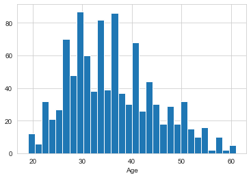

```python
sns.set_style('whitegrid')
data['Age'].hist(bins=30)
plt.xlabel('Age')
```

جوینت پلات درآمد بر حسب سن را رسم می کنیم.

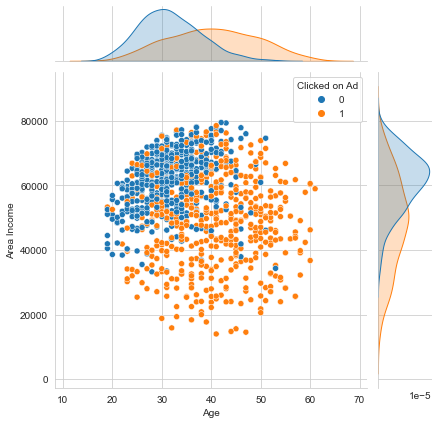

```python
sns.jointplot(x='Age' ,y='Area Income', data=data, hue='Clicked on Ad')
```

KDE پلات میزان وقت گذاشته شده روی سایت تبلیغ بر حسب سن را رسم می کنیم.

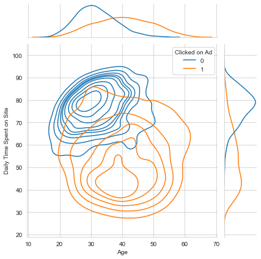

```python
sns.jointplot(x='Age', y='Daily Time Spent on Site', data=data, kind='kde', color='red', hue='Clicked on Ad')
```

جوینت پلات میزان استفاده از اینترنت بر حسب میزان وقت گذاشته شده روی سایت تبلیغ را رسم می کنیم.

```python
data.columns
```

```
Index(['Daily Time Spent on Site', 'Age', 'Area Income',
       'Daily Internet Usage', 'Ad Topic Line', 'City', 'Male', 'Country',
       'Timestamp', 'Clicked on Ad'],
      dtype='object')
```

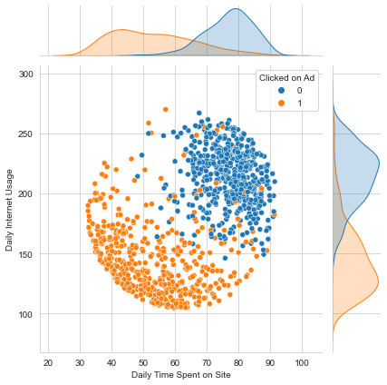

```python
sns.jointplot(x='Daily Time Spent on Site', y='Daily Internet Usage', data=data, color='green', hue='Clicked on Ad')
```

در نهایت یک Pain Plot کلی برای دیتاست، با مشخص کردن تفاوت کسانی که روی تبلیغ کلیک کرده اند و نکرده اند را رسم کنید.

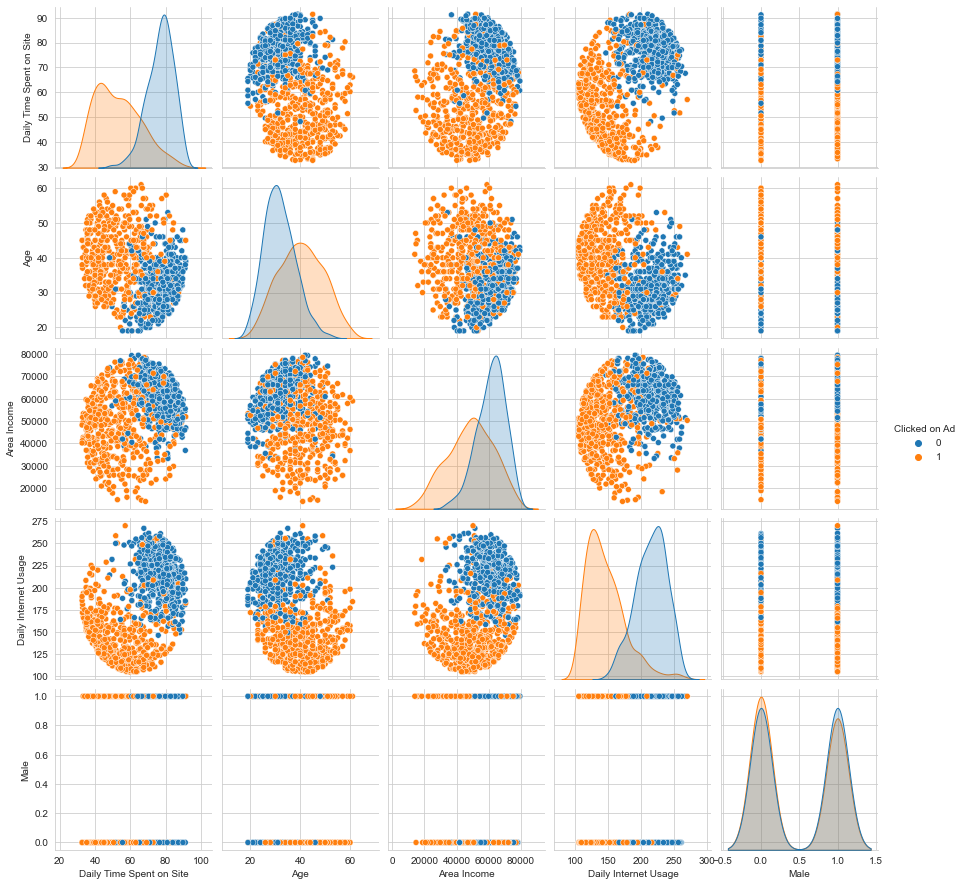

```python
sns.pairplot(data, hue='Clicked on Ad')
```

# Logistic Regression

پس از ایمپورت متد مربوطه، داده ها را به دو بخش فیچر و لیبل تقسیم کنید و سپس آن ها را به دو بخش ترین و تست تقسیم نمایید.

```python
data.head()
```

|  | Daily Time Spent on Site | Age | Area Income | Daily Internet Usage | Ad Topic Line | City | Male | Country | Timestamp | Clicked on Ad |
| --- | --- | --- | --- | --- | --- | --- | --- | --- | --- | --- |
| 0 | 68.95 | 35 | 61833.90 | 256.09 | Cloned 5thgeneration orchestration | Wrightburgh | 0 | Tunisia | 2016-03-27 00:53:11 | 0 |
| 1 | 80.23 | 31 | 68441.85 | 193.77 | Monitored national standardization | West Jodi | 1 | Nauru | 2016-04-04 01:39:02 | 0 |
| 2 | 69.47 | 26 | 59785.94 | 236.50 | Organic bottom-line service-desk | Davidton | 0 | San Marino | 2016-03-13 20:35:42 | 0 |
| 3 | 74.15 | 29 | 54806.18 | 245.89 | Triple-buffered reciprocal time-frame | West Terrifurt | 1 | Italy | 2016-01-10 02:31:19 | 0 |
| 4 | 68.37 | 35 | 73889.99 | 225.58 | Robust logistical utilization | South Manuel | 0 | Iceland | 2016-06-03 03:36:18 | 0 |

```python
x = data.drop(['Clicked on Ad','Ad Topic Line','City','Country','Timestamp'], axis=1)
y = data['Clicked on Ad']
```

```python
from sklearn.model_selection import train_test_split
x_train, x_test, y_train, y_test = train_test_split(x, y, test_size=0.3, random_state=101)
```

حالا کلاس رگرسیون لاجستیک را بارگزاری نمایید و یک مدل از آن نوع بسازید و با داده های ترین آموزش دهید.

```python
from sklearn.linear_model import LogisticRegression
logmodel = LogisticRegression()
```

```python
logmodel.fit(x_train, y_train)
```

```
LogisticRegression()
```

## Predictions and Evaluations

حالا به کمک مدلی که آموزش داده اید، برای داده های تست پیش بینی کنید که کدام یک روی تبلیغ ها کلیک می کنند.

```python
pred = logmodel.predict(x_test)
```

حالا برای مدلی که آموزش داده اید، معیار های ارزیابی همچون Score و Confusion Matrix و Classification Report را بررسی کنید.

```python
logmodel.score(x_test, y_test)
```

```
0.9266666666666666
```

```python
from sklearn.metrics import classification_report, confusion_matrix
print(classification_report(pred, y_test))
print('***********','\n')
print(confusion_matrix(pred, y_test))
```

```
              precision    recall  f1-score   support

           0       0.95      0.91      0.93       163
           1       0.90      0.94      0.92       137

    accuracy                           0.93       300
   macro avg       0.93      0.93      0.93       300
weighted avg       0.93      0.93      0.93       300

***********

[[149  14]
 [  8 129]]
```

#### حالا میخوام روز های خفته رو هم دخالت بدم توو یادگیری مدلم

```python
data['Timestamp'] = pd.to_datetime(data['Timestamp'])
```

```python
data.rename({'Timestamp' : 'DOF'}, axis=1, inplace=True)
```

```python
data
```

|  | Daily Time Spent on Site | Age | Area Income | Daily Internet Usage | Ad Topic Line | City | Male | Country | DOF | Clicked on Ad |
| --- | --- | --- | --- | --- | --- | --- | --- | --- | --- | --- |
| 0 | 68.95 | 35 | 61833.90 | 256.09 | Cloned 5thgeneration orchestration | Wrightburgh | 0 | Tunisia | 2016-03-27 00:53:11 | 0 |
| 1 | 80.23 | 31 | 68441.85 | 193.77 | Monitored national standardization | West Jodi | 1 | Nauru | 2016-04-04 01:39:02 | 0 |
| 2 | 69.47 | 26 | 59785.94 | 236.50 | Organic bottom-line service-desk | Davidton | 0 | San Marino | 2016-03-13 20:35:42 | 0 |
| 3 | 74.15 | 29 | 54806.18 | 245.89 | Triple-buffered reciprocal time-frame | West Terrifurt | 1 | Italy | 2016-01-10 02:31:19 | 0 |
| 4 | 68.37 | 35 | 73889.99 | 225.58 | Robust logistical utilization | South Manuel | 0 | Iceland | 2016-06-03 03:36:18 | 0 |
| ... | ... | ... | ... | ... | ... | ... | ... | ... | ... | ... |
| 995 | 72.97 | 30 | 71384.57 | 208.58 | Fundamental modular algorithm | Duffystad | 1 | Lebanon | 2016-02-11 21:49:00 | 1 |
| 996 | 51.30 | 45 | 67782.17 | 134.42 | Grass-roots cohesive monitoring | New Darlene | 1 | Bosnia and Herzegovina | 2016-04-22 02:07:01 | 1 |
| 997 | 51.63 | 51 | 42415.72 | 120.37 | Expanded intangible solution | South Jessica | 1 | Mongolia | 2016-02-01 17:24:57 | 1 |
| 998 | 55.55 | 19 | 41920.79 | 187.95 | Proactive bandwidth-monitored policy | West Steven | 0 | Guatemala | 2016-03-24 02:35:54 | 0 |
| 999 | 45.01 | 26 | 29875.80 | 178.35 | Virtual 5thgeneration emulation | Ronniemouth | 0 | Brazil | 2016-06-03 21:43:21 | 1 |

1000 rows × 10 columns

```python
categorical_day = pd.get_dummies(data['DOF'].apply(lambda x:x.dayofweek))
data = pd.concat([data, categorical_day], axis=1)
```

```python
data
```

|  | Daily Time Spent on Site | Age | Area Income | Daily Internet Usage | Ad Topic Line | City | Male | Country | DOF | Clicked on Ad | 0 | 1 | 2 | 3 | 4 | 5 | 6 |
| --- | --- | --- | --- | --- | --- | --- | --- | --- | --- | --- | --- | --- | --- | --- | --- | --- | --- |
| 0 | 68.95 | 35 | 61833.90 | 256.09 | Cloned 5thgeneration orchestration | Wrightburgh | 0 | Tunisia | 2016-03-27 00:53:11 | 0 | 0 | 0 | 0 | 0 | 0 | 0 | 1 |
| 1 | 80.23 | 31 | 68441.85 | 193.77 | Monitored national standardization | West Jodi | 1 | Nauru | 2016-04-04 01:39:02 | 0 | 1 | 0 | 0 | 0 | 0 | 0 | 0 |
| 2 | 69.47 | 26 | 59785.94 | 236.50 | Organic bottom-line service-desk | Davidton | 0 | San Marino | 2016-03-13 20:35:42 | 0 | 0 | 0 | 0 | 0 | 0 | 0 | 1 |
| 3 | 74.15 | 29 | 54806.18 | 245.89 | Triple-buffered reciprocal time-frame | West Terrifurt | 1 | Italy | 2016-01-10 02:31:19 | 0 | 0 | 0 | 0 | 0 | 0 | 0 | 1 |
| 4 | 68.37 | 35 | 73889.99 | 225.58 | Robust logistical utilization | South Manuel | 0 | Iceland | 2016-06-03 03:36:18 | 0 | 0 | 0 | 0 | 0 | 1 | 0 | 0 |
| ... | ... | ... | ... | ... | ... | ... | ... | ... | ... | ... | ... | ... | ... | ... | ... | ... | ... |
| 995 | 72.97 | 30 | 71384.57 | 208.58 | Fundamental modular algorithm | Duffystad | 1 | Lebanon | 2016-02-11 21:49:00 | 1 | 0 | 0 | 0 | 1 | 0 | 0 | 0 |
| 996 | 51.30 | 45 | 67782.17 | 134.42 | Grass-roots cohesive monitoring | New Darlene | 1 | Bosnia and Herzegovina | 2016-04-22 02:07:01 | 1 | 0 | 0 | 0 | 0 | 1 | 0 | 0 |
| 997 | 51.63 | 51 | 42415.72 | 120.37 | Expanded intangible solution | South Jessica | 1 | Mongolia | 2016-02-01 17:24:57 | 1 | 1 | 0 | 0 | 0 | 0 | 0 | 0 |
| 998 | 55.55 | 19 | 41920.79 | 187.95 | Proactive bandwidth-monitored policy | West Steven | 0 | Guatemala | 2016-03-24 02:35:54 | 0 | 0 | 0 | 0 | 1 | 0 | 0 | 0 |
| 999 | 45.01 | 26 | 29875.80 | 178.35 | Virtual 5thgeneration emulation | Ronniemouth | 0 | Brazil | 2016-06-03 21:43:21 | 1 | 0 | 0 | 0 | 0 | 1 | 0 | 0 |

1000 rows × 17 columns

```python
data.drop(['DOF'], axis=1, inplace=True)
```

```python
data
```

|  | Daily Time Spent on Site | Age | Area Income | Daily Internet Usage | Ad Topic Line | City | Male | Country | Clicked on Ad | 0 | 1 | 2 | 3 | 4 | 5 | 6 |
| --- | --- | --- | --- | --- | --- | --- | --- | --- | --- | --- | --- | --- | --- | --- | --- | --- |
| 0 | 68.95 | 35 | 61833.90 | 256.09 | Cloned 5thgeneration orchestration | Wrightburgh | 0 | Tunisia | 0 | 0 | 0 | 0 | 0 | 0 | 0 | 1 |
| 1 | 80.23 | 31 | 68441.85 | 193.77 | Monitored national standardization | West Jodi | 1 | Nauru | 0 | 1 | 0 | 0 | 0 | 0 | 0 | 0 |
| 2 | 69.47 | 26 | 59785.94 | 236.50 | Organic bottom-line service-desk | Davidton | 0 | San Marino | 0 | 0 | 0 | 0 | 0 | 0 | 0 | 1 |
| 3 | 74.15 | 29 | 54806.18 | 245.89 | Triple-buffered reciprocal time-frame | West Terrifurt | 1 | Italy | 0 | 0 | 0 | 0 | 0 | 0 | 0 | 1 |
| 4 | 68.37 | 35 | 73889.99 | 225.58 | Robust logistical utilization | South Manuel | 0 | Iceland | 0 | 0 | 0 | 0 | 0 | 1 | 0 | 0 |
| ... | ... | ... | ... | ... | ... | ... | ... | ... | ... | ... | ... | ... | ... | ... | ... | ... |
| 995 | 72.97 | 30 | 71384.57 | 208.58 | Fundamental modular algorithm | Duffystad | 1 | Lebanon | 1 | 0 | 0 | 0 | 1 | 0 | 0 | 0 |
| 996 | 51.30 | 45 | 67782.17 | 134.42 | Grass-roots cohesive monitoring | New Darlene | 1 | Bosnia and Herzegovina | 1 | 0 | 0 | 0 | 0 | 1 | 0 | 0 |
| 997 | 51.63 | 51 | 42415.72 | 120.37 | Expanded intangible solution | South Jessica | 1 | Mongolia | 1 | 1 | 0 | 0 | 0 | 0 | 0 | 0 |
| 998 | 55.55 | 19 | 41920.79 | 187.95 | Proactive bandwidth-monitored policy | West Steven | 0 | Guatemala | 0 | 0 | 0 | 0 | 1 | 0 | 0 | 0 |
| 999 | 45.01 | 26 | 29875.80 | 178.35 | Virtual 5thgeneration emulation | Ronniemouth | 0 | Brazil | 1 | 0 | 0 | 0 | 0 | 1 | 0 | 0 |

1000 rows × 16 columns

```python
x = data.drop(['Daily Internet Usage','City','Ad Topic Line','Country','Clicked on Ad'], axis=1)
y = data['Clicked on Ad']
```

```python
from sklearn.model_selection import train_test_split
x_train, x_test, y_train, y_test = train_test_split(x, y, test_size=0.3, random_state=101)
```

```python
from sklearn.linear_model import LogisticRegression
logmodel2 = LogisticRegression()
```

```python
logmodel2.fit(x_train, y_train)
```

```
LogisticRegression()
```

```python
pred2 = logmodel2.predict(x_test)
```

```python
logmodel2.score(x_test, y_test)
```

```
0.9266666666666666
```

```python
from sklearn.metrics import classification_report, confusion_matrix
```

```python
print(confusion_matrix(pred2, y_test))
```

```
[[147  12]
 [ 10 131]]
```

```python
print(classification_report(pred2, y_test))
```

```
              precision    recall  f1-score   support

           0       0.94      0.92      0.93       159
           1       0.92      0.93      0.92       141

    accuracy                           0.93       300
   macro avg       0.93      0.93      0.93       300
weighted avg       0.93      0.93      0.93       300
```

# The End :)